# BSGatlas: Transcripts

Adrian Geissler, Christian Anthon, Stefan Seemann and Jan Gorodkin

Center for non-coding RNA in Technology and Health, Department of Veterinary and Animal Sciences, University of Copenhagen, Denmark  
Corresponding author

2019-06-18 11:14:17

# 1 Transcripts and operons

## 1.1 Data

BsubCyc’s database provides easy access to $1,602$ transcriptional units.

SubtiWiki is a still active community effort for protein-centric \Bsub annotation. It provides a magnitude of meta information, such as its gene categorisation and lists of transcriptional regulations and interactions. Moreover, its most recent version included some parts of BsubCyc, yet and the curated list of transcription start, termination sites, and functional annotation via GO terms were not. Unfortunately, SubtiWiki does not provide the export of gene coordinates, such that we had to restore these from our merged gene set via comparison of locus and gene names and synonyms. Of initially 5,999 coding/non-coding genes, structures, and untranslated regions described in SubtiWiki, we were unable to identify 16 genes that seem either putative or after manual investigation had a sligthly different spelling in the gene name. The UTR information was ignored, as the underlying study prooved to have classification difficulties (see below). With exception to the afore mentioned very short peptide predictions that we found to have unclear gene coordinates, the remaining 4,615 subtwiki genes were unambiguously matched to our merged gene set. In comparison, the merged set contains 168 genes not described in the subtiwiki set, these were 70 coding genes, 54 riboswitches, 24 sRNAs, 10 putative coding genes, 6 known RNAs with known regulatory antisense regulations, and 4 more ncRNAs.

We were able to parse of the intially 2,267 transcripts 2,259 of which only 10 had gene references that we were unable to resolve. In addition, we retrieved 5,297 transcriptional regulation pairs and 2,567 protein-protein, RNA-protein, and RNA-RNA interactions.

The authors of the database of transcriptional regulation in Bacillus subtilis (DBTBS) provides us with their latest annotation in an XML format. Unfortunately, this file did not contain coordinates for the most recent Bsub reference genome sequence. We utilized the Biostrings exact sequence lookup to find coordinates for 98% of the 1,262 annotated transcription factor binding sites and for 90% of the 1,031 annotated transcript termination sites. To reduce erranous or ambiguous annotations, we used only unique matches without allowed mismatches. From the sigma factor binding sites that have the relative position to the TSS provided, we were able to infer 665 high resolution TSSs.

DBTBS provides curated annotaiton of operons for 2,201 genes. For 98.9% of these genes we were able to find the corresponding gene in our merged set by comparing the gene names and keeping only unambguous matches. Due to the high matching rate, for allmost all (98.6%) of the annotated 1,123 operons are complete.

## 1.2 Processing

We complemented the transcriptional units (TU) from DBTBS, SubtiWiki, and BsubCyc with genes and RNA structures from our merged gene set by checking for overlaps. We investigated the overlaps and found two main cases: Either genes were fully contained by a transcriptional unit, or a gene or strucutre has a large overlap with a transcriptional unit, possibly to the extend that it fully contains it. The latter was the case for a small peptide sequence that overlaps is fully contained in a known small regulatory RNA. Thus, we decided to add a gene or structure to a TU if (a) it is fully contained by the TU, (b) if it contains the TU, (c) or the overlap relative to the length of the gene is at least 70%. Overall, we added genes to 46 TUs from BsubCyc, 753 TUs of DBTBS, and 1968 TUs from SubtiWiki.

Afterwards we unified the list of TUs and combined these that contained the exact same genes. All resources share 979 TUs, each resource has a unique set of TUs that are not contained in neither of them.

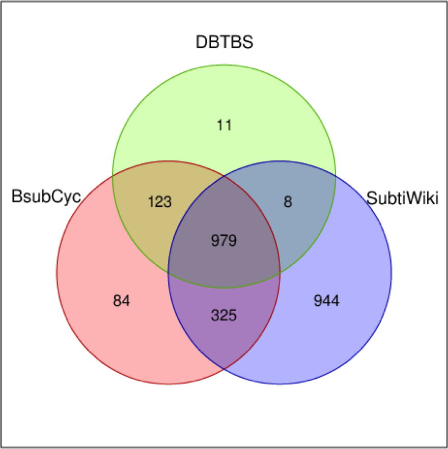

We removed two transcripts, one from DBTBS and SubtiWiki each, that seem erranous as they would span more than a quarter of the whole genome. Afterwards, the set of unified TUs contained a total of $2,474$ TUs.

Under the assumption, that two transcripts that share at least one gene, we computationally inferred a set of $1,897$ operons with a graph based approach. In the graph the nodes represented the TUs and genes with undirectional edges added if a gene is part of a TU. 99.2% of all computed operons have a TU that contains all genes of the operon. We also computed the distribution of genes and isoforms per computed operon (see fig). These vizually look similar to those distribution computed in a recent study in Streptococcus pneumoniae. This organism is in the same phylum (Firmicutes) as Bsub, such that we overall assume that the computed operons correctly represent the biology.

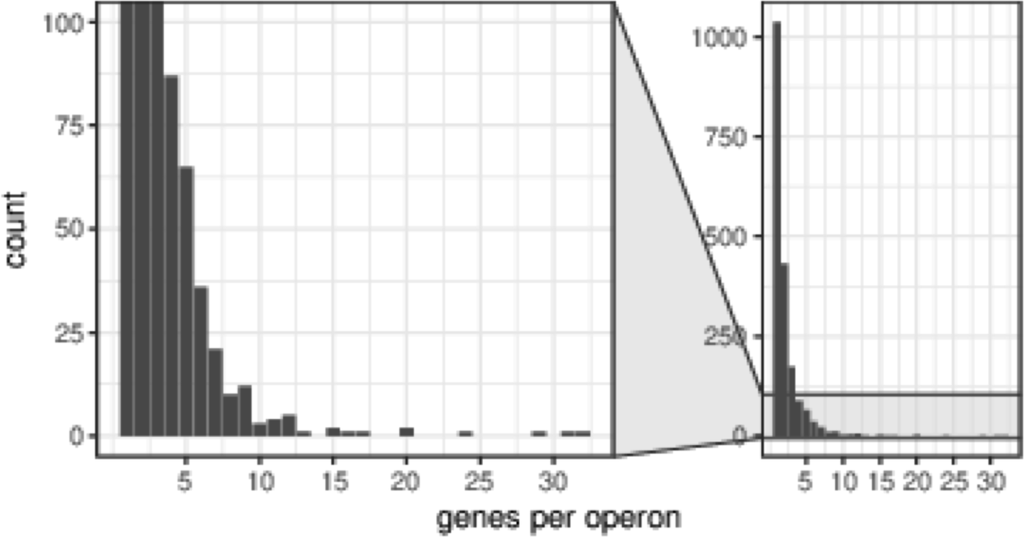

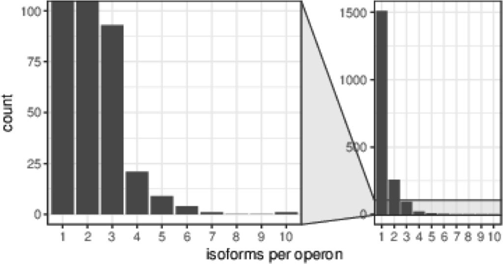

For each computed operon, we investigated from which resource (see above) the annotation originates, and how many genes of the genome are associated with a TU by only using a single resource.

DBTBS provides TUs for only 46% of all genes, BsubCyc for 57%, and SubtiWiki for 81%. However, the combination of these resources provide annotation of TUs for addtional 3% of all genes, and a set of around 220 TUs more than dscribed in SubtiWiki.

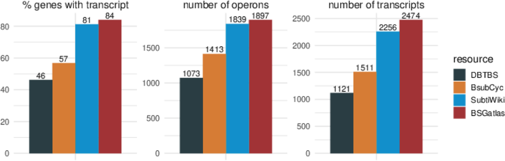